# GRAM Simulation

Calibration and Benchmarking - Exploration of Scenarios

Sigal Maya

Updated 03/06/2025

# Comparison of synthetic cohort to US population

Table 1. Representativeness of synthetic cohort of the US population

| Attribute |  | Modeled Value | Benchmark Value | Source |
| --- | --- | --- | --- | --- |
| n |  | 10000 |  |  |
| AGE (mean (SD)) |  | 50.00 (0.00) |  |  |
| SEX (%) | Male | 4991 ( 49.9) | 49.0% | ACS data |
|  | Female | 5009 ( 50.1) | 51.0% | ACS data |
| RACEETH (%) | Non-Hispanic White | 6263 ( 62.6) | 64.0% | ACS data |
|  | Non-Hispanic Black | 1361 ( 13.6) | 14.0% | ACS data |
|  | Hispanic | 2376 ( 23.8) | 22.0% | ACS data |
| EDU (mean (SD)) |  | 13.66 (3.55) | 13.6 (??) | UNDP-HDI |
| INCOME (%) | Low Income | 283 ( 2.8) | 5.0% | ACS data |
|  | Medium Income | 1065 ( 10.7) | 17.0% | ACS data |
|  | High Income | 8652 ( 86.5) | 78.0% | ACS data |
| MEDBUR (mean (SD)) |  | 2.56 (1.95) | 2.25 (??) | Mossadeghi et al 2023 |
| APOE4 (%) | Not Carrier | 7471 ( 74.7) | 75.0% | Di Battista et al 2016 |
|  | Carrier | 2529 ( 25.3) | 25.0% | Di Battista et al 2016 |
| SYN (%) | Cognitively Healthy | 10000 (100.0) |  |  |

Starting population seems to line up well with empirical data, as expected. Income categories are imperfect, because benchmark data categorization uses slightly different income cutoffs (e.g., low income in model is defined as <9,000/yr, whereas benchmark data is <10,000/yr).

# Comparison of modeled mortality with empirical mortality data

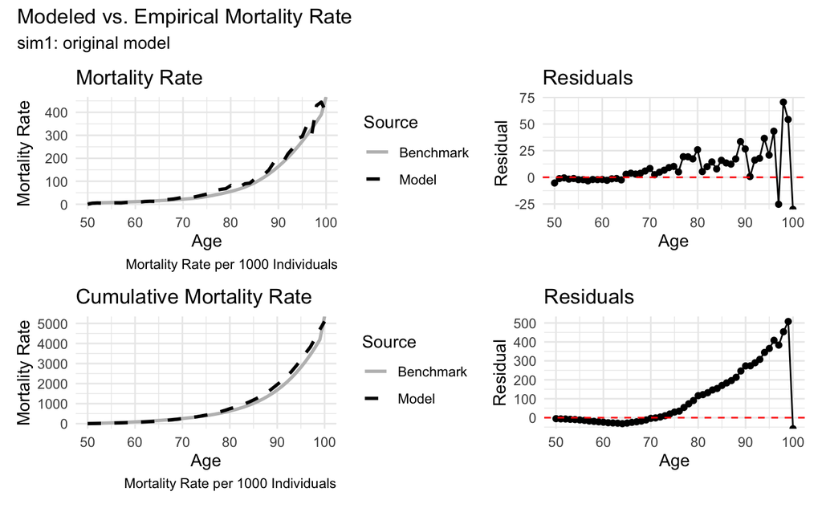

These rates are per 1000, so we are up to 50% off… Assuming the above reasoning is accurate, let’s reduce baseline mortality.

## Reduced mortality after age 70

Mortality rates adjusted iteratively, by looking at the residuals for annual mortality rate. In final sim3, baseline mortality was adjusted as follows:

| Age | Adjustment Factor |
| --- | --- |
| 50-60 | 1.50 |
| 61-70 | 1.00 |
| 71-80 | 0.75 |
| 81-90 | 0.85 |
| 91-100 | 0.95 |

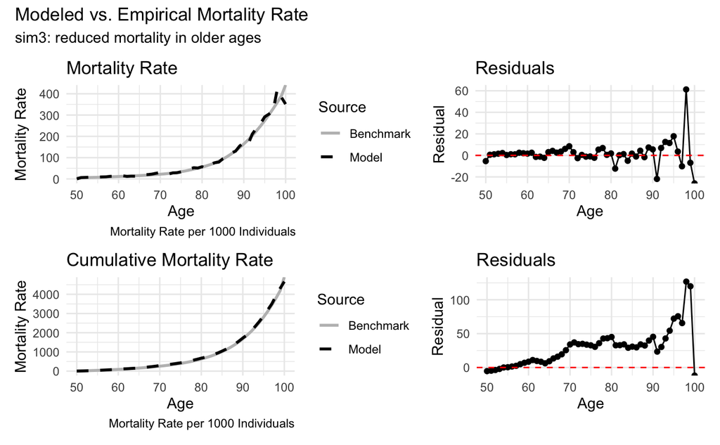

That’s better. Keeping sim3 with the adjusted mortality rates. Annual error ranges from -2.5% to 6.0%. Cumulative mortality error is approximately 12%.

# Comparison of MCI and dementia prevalence by race and age

Benchmark data from [Manly et al 2022 (Table 2)](https://jamanetwork.com/journals/jamaneurology/fullarticle/2797274), based on a nationally representative cohort of adults 65+, including healthy agers. Benchmark prevalence values by race/ethnicity were not further disaggregated by age, so they are shown at the sample mean age.

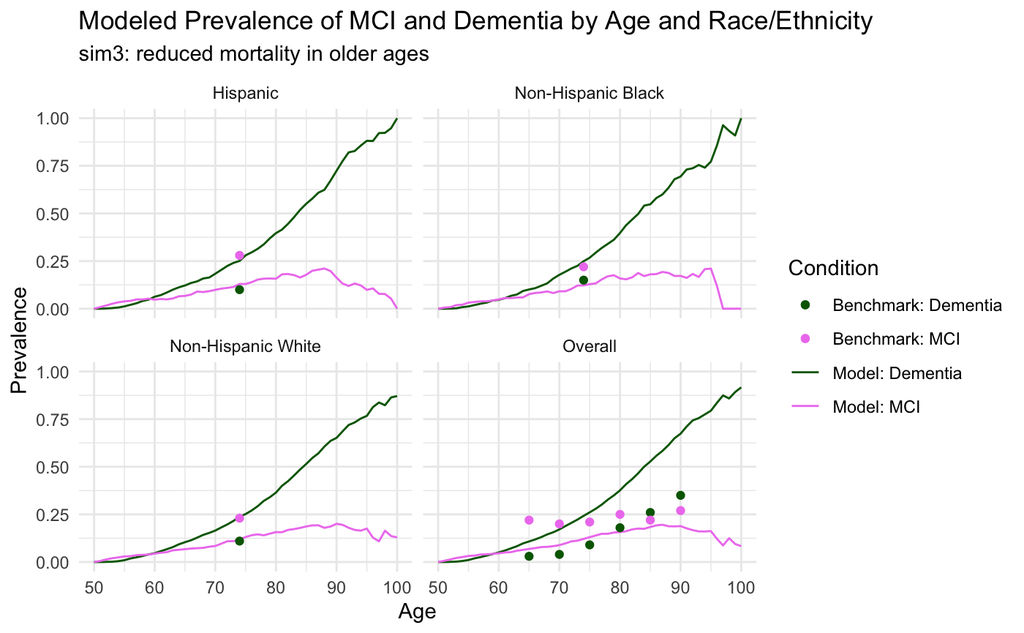

Very poor fit (this is with the adjusted mortality rates). MCI prevalence in model is too low, and dementia is too high. Potential reasons:

1. MCI incidence is too low.

[figure not shown]

[figure not shown]

[figure not shown]

1. We start with a healthy cohort, so it takes time for MCI prevalence to rise. Try starting with a prevalent cohort (`sim4`).

[figure not shown]

That did not solve the issue.

1. People progress to dementia quickly and don’t spend enough time in MCI such that with new cases prevalence would rise (but noting that our reside time estimates were spot on). Try decreasing CDR progression rate while in MCI (`sim5`).

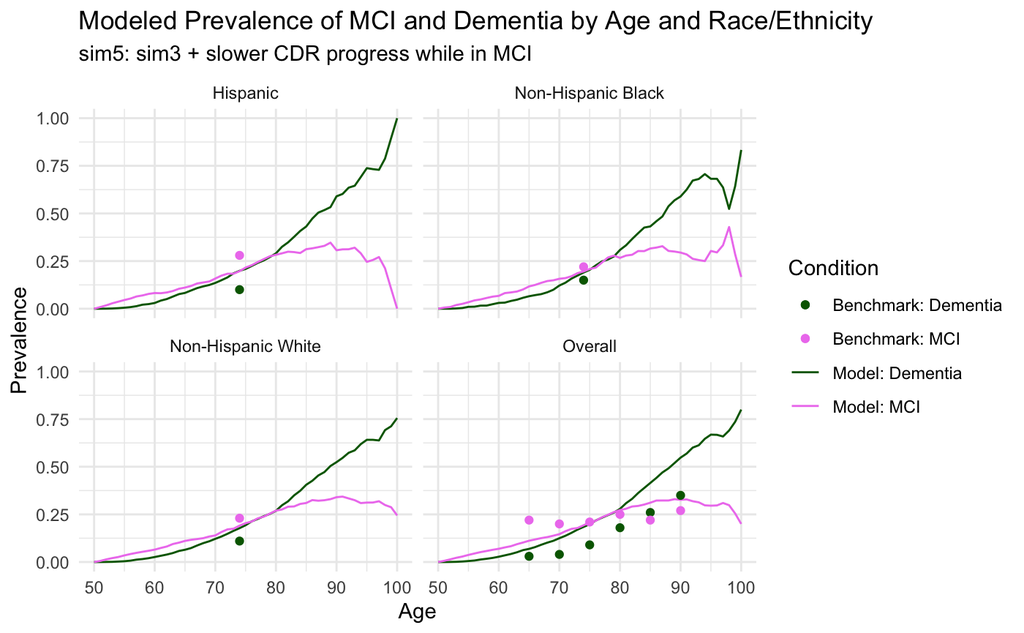

That’s much better. Try combining the above two changes in `sim6`:

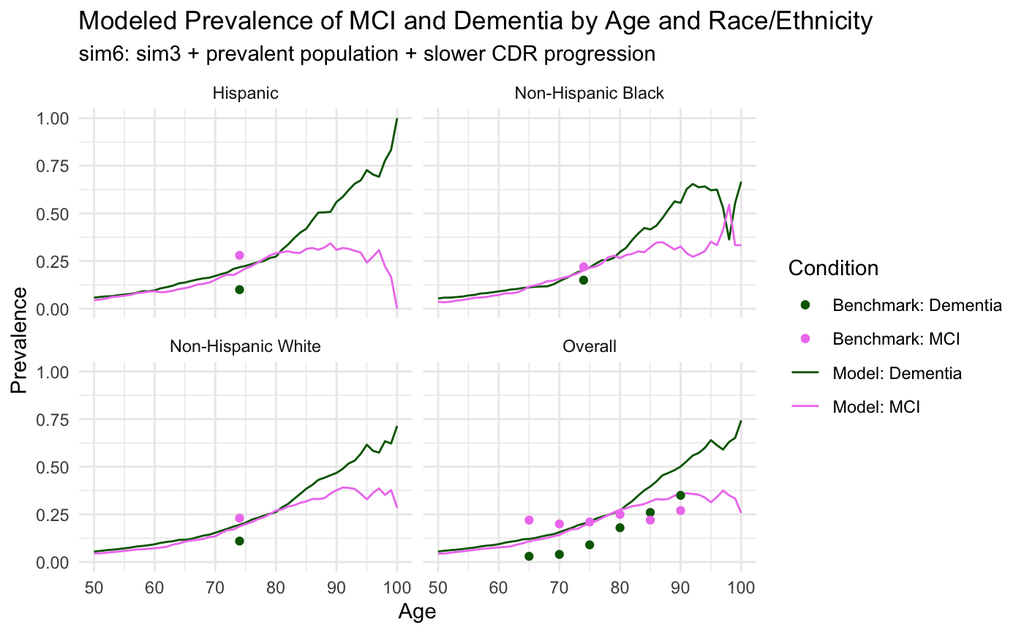

This will have changed mortality. Reviewing mortality for `sim6`:

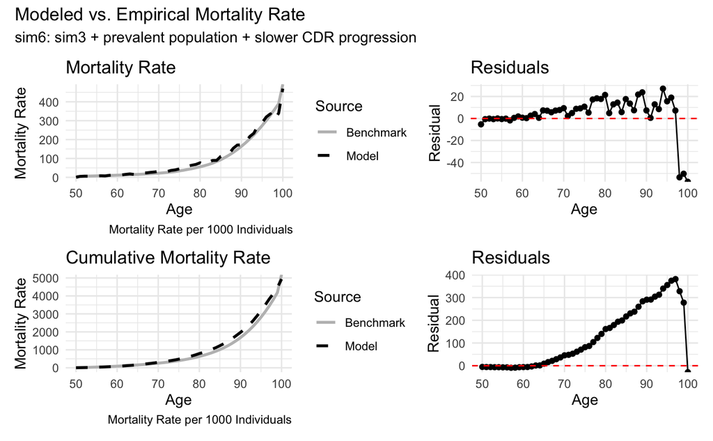

Also note that Alzheimer’s Association reports slightly lower values (12-18% MCI among those 60 and older).

The model adjusts baseline MCI hazard rates to account for mix of risk factors in the population (i.e., remove the effect of risk factors that are present in published rates, so that they can be added back in during the simulation). This adjustment factor is arbitrarily set at 4. In `sim7`, try a different adjustment factor: no adjustment up to age 70, 50% increase after age 71.

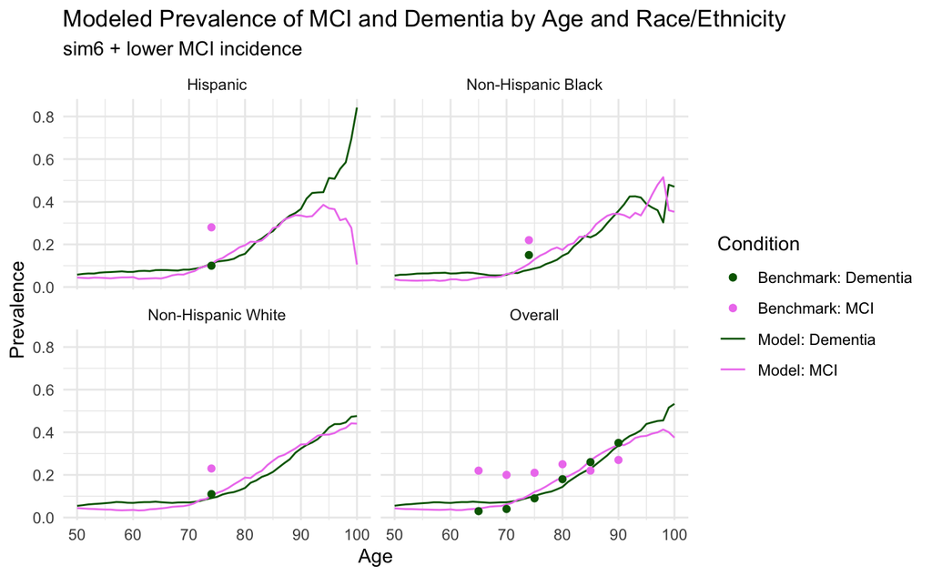

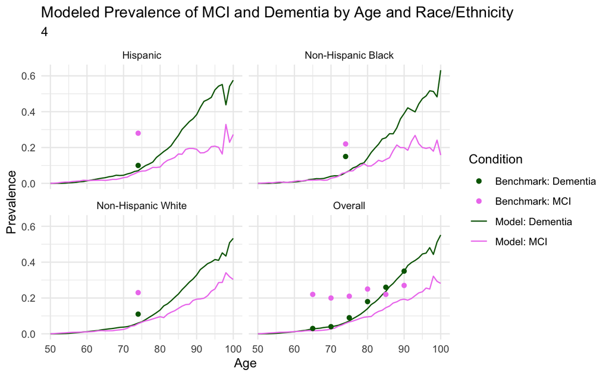

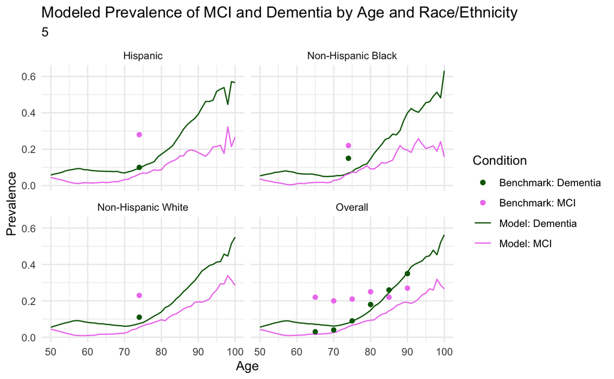

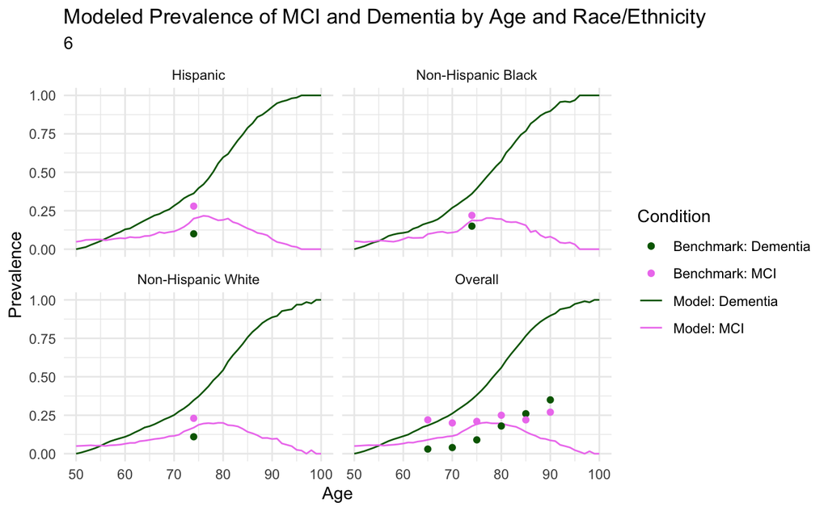

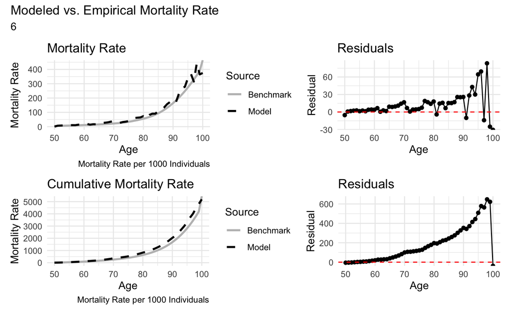

Mortality is again a bit too high. Reduce again.

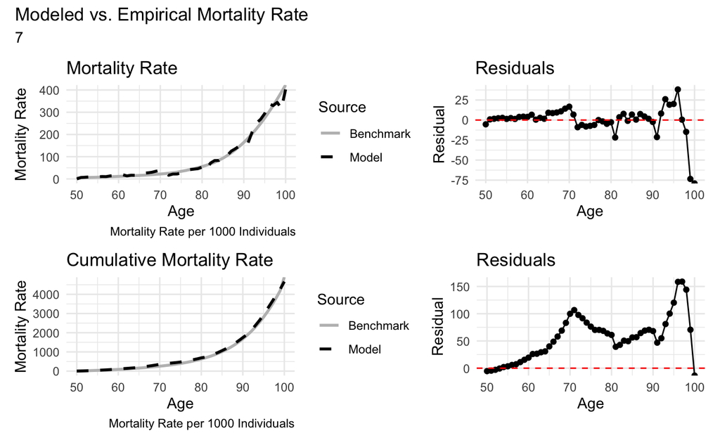

Now look again at prevalence:

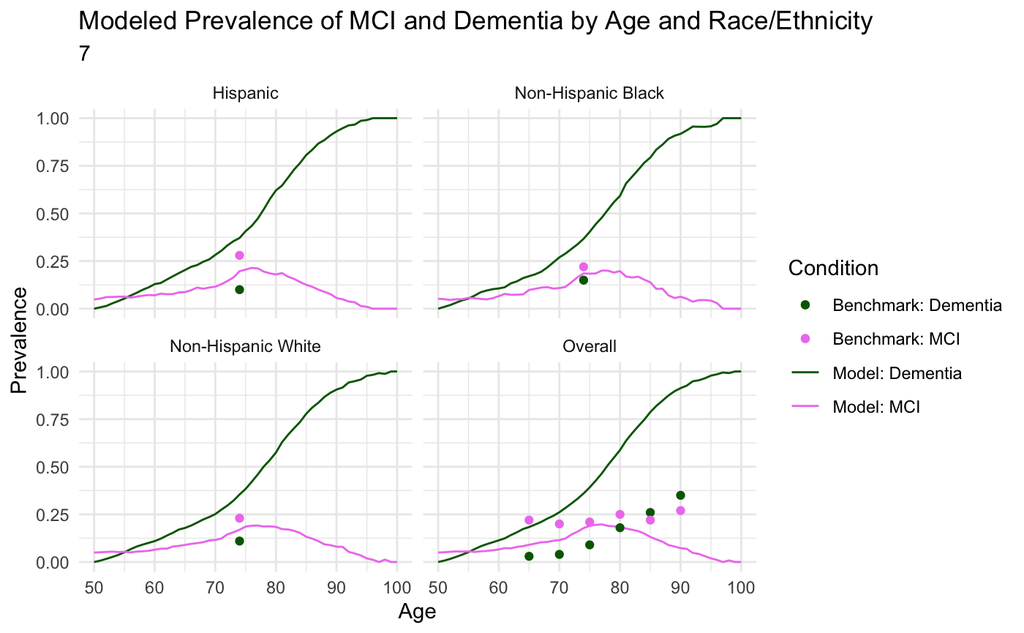

# Reside time in MCI and dementia by age of onset

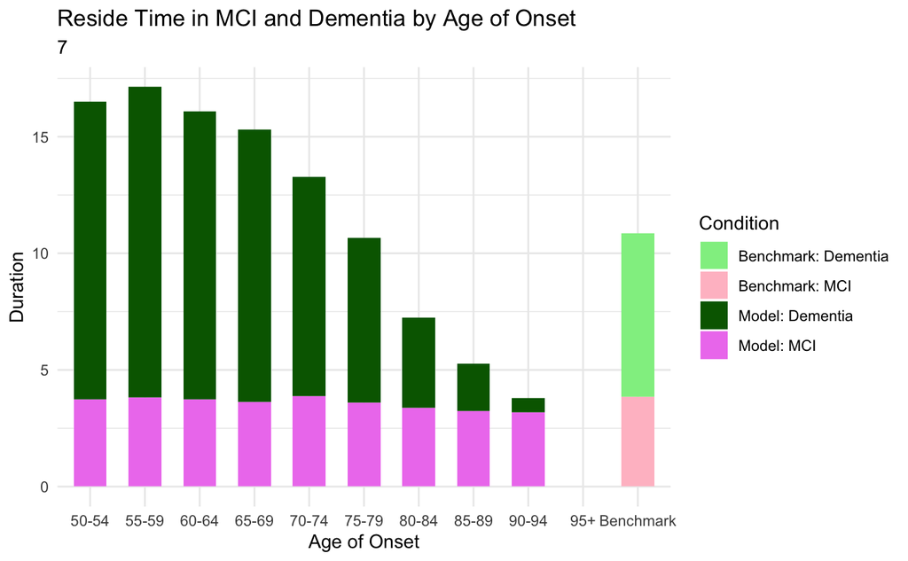

# Compare average age on MCI onset

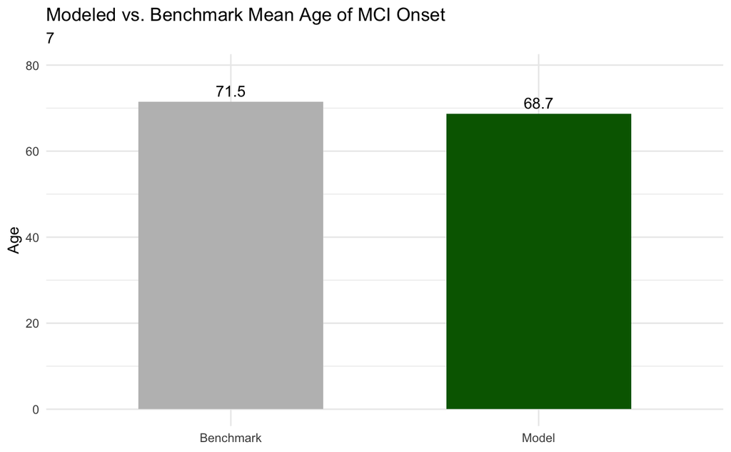